# Study on the births in the USA from 2017 to 2018

## What is the proportion of boys and girls? Has it changed between 2017 and 2018?

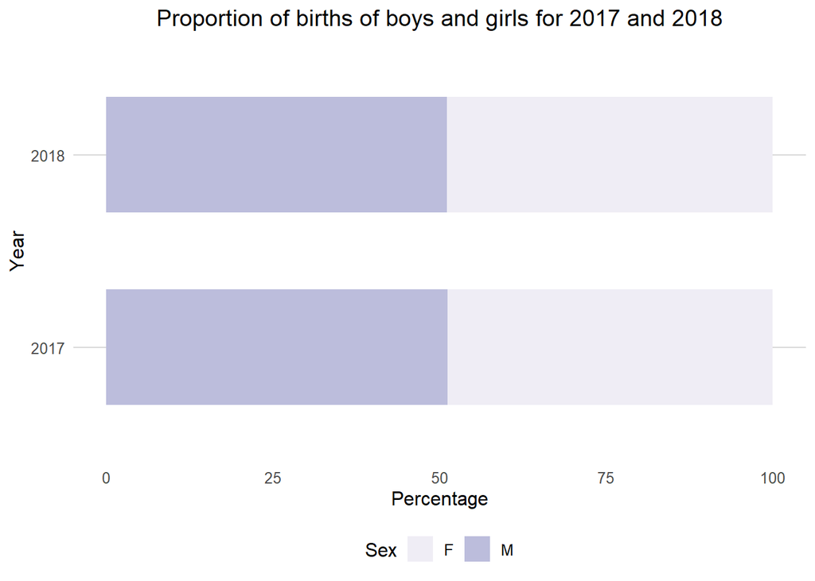

The number of births of boys seems to be pretty similar to the number of births of girls, **as 48.8282307 % of the births in 2017 were girls**, and **51.1717693 % were boys.**

In 2018, the **results were similar to those of 2017**, as 51.1181276 % of the births were boys and 48.8818724 % were girls.

## What is the average birth weight in grams?

The average birth weight of the children in the USA is **3262 grams**, which corresponds to **3.262 kilograms.**

## Density plot of the birth weight per sex in 2018

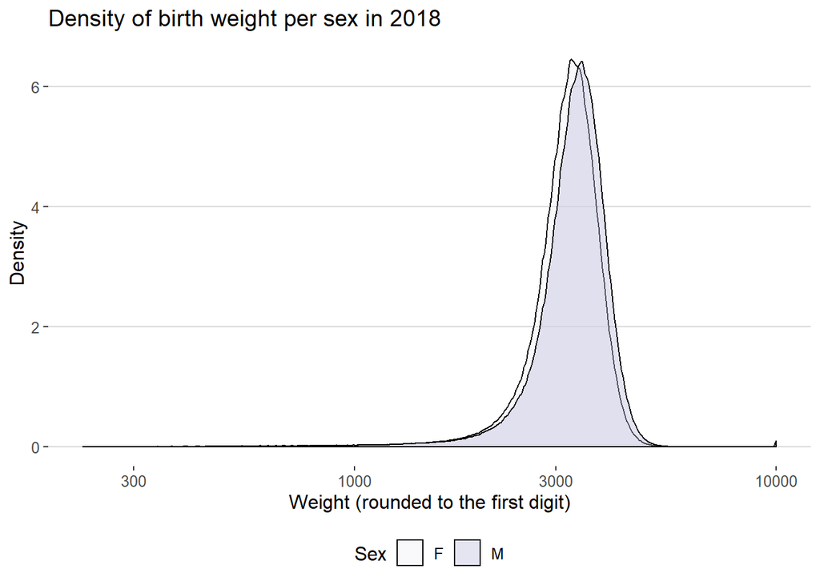

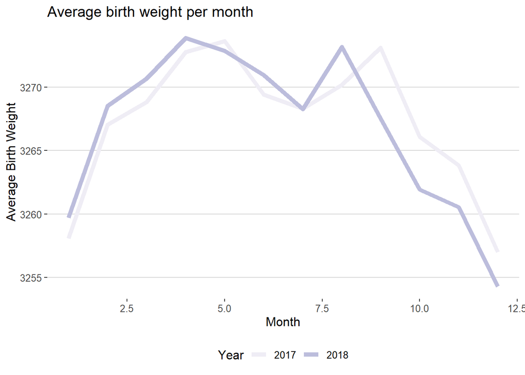

**Average birth weight seems to vary very little from years to years** and also seems to **follow the same trend**: for example, the average birth weight is lower in January and December in both years, compared to the other months.